Hosting and using model After Deployment by Ojash Adhikari

```python
bucket='c89855a1950770l4487067t1w161529914884-labbucket-1ix6zgcikukz2'
#bucket from previous session
```

```python
import warnings, requests, zipfile, io
warnings.simplefilter('ignore')
import pandas as pd
from scipy.io import arff

import os
import boto3
import sagemaker
from sagemaker.image_uris import retrieve
from sklearn.model_selection import train_test_split
```

```python
#Activity from section 5: training and selection of model
f_zip = 'http://archive.ics.uci.edu/ml/machine-learning-databases/00212/vertebral_column_data.zip'
r = requests.get(f_zip, stream=True)
Vertebral_zip = zipfile.ZipFile(io.BytesIO(r.content))
Vertebral_zip.extractall()

data = arff.loadarff('column_2C_weka.arff')
df = pd.DataFrame(data[0])

class_mapper = {b'Abnormal':1,b'Normal':0}
df['class']=df['class'].replace(class_mapper)

cols = df.columns.tolist()
cols = cols[-1:] + cols[:-1]
df = df[cols]

train, test_and_validate = train_test_split(df, test_size=0.2, random_state=42, stratify=df['class'])
test, validate = train_test_split(test_and_validate, test_size=0.5, random_state=42, stratify=test_and_validate['class'])

prefix='lab3'

train_file='vertebral_train.csv'
test_file='vertebral_test.csv'
validate_file='vertebral_validate.csv'

s3_resource = boto3.Session().resource('s3')
def upload_s3_csv(filename, folder, dataframe):
    csv_buffer = io.StringIO()
    dataframe.to_csv(csv_buffer, header=False, index=False )
    s3_resource.Bucket(bucket).Object(os.path.join(prefix, folder, filename)).put(Body=csv_buffer.getvalue())

upload_s3_csv(train_file, 'train', train)
upload_s3_csv(test_file, 'test', test)
upload_s3_csv(validate_file, 'validate', validate)

container = retrieve('xgboost',boto3.Session().region_name,'1.0-1')

hyperparams={"num_round":"42",
             "eval_metric": "auc",
             "objective": "binary:logistic"}

s3_output_location="s3://{}/{}/output/".format(bucket,prefix)
xgb_model=sagemaker.estimator.Estimator(container,
                                       sagemaker.get_execution_role(),
                                       instance_count=1,
                                       instance_type='ml.m4.xlarge',
                                       output_path=s3_output_location,
                                        hyperparameters=hyperparams,
                                        sagemaker_session=sagemaker.Session())

train_channel = sagemaker.inputs.TrainingInput(
    "s3://{}/{}/train/".format(bucket,prefix,train_file),
    content_type='text/csv')

validate_channel = sagemaker.inputs.TrainingInput(
    "s3://{}/{}/validate/".format(bucket,prefix,validate_file),
    content_type='text/csv')

data_channels = {'train': train_channel, 'validation': validate_channel}

xgb_model.fit(inputs=data_channels, logs=False)

print('ready for hosting!')
```

```
INFO:sagemaker:Creating training-job with name: sagemaker-xgboost-2023-07-26-08-35-48-693
```

```
2023-07-26 08:35:48 Starting - Starting the training job......
2023-07-26 08:36:29 Starting - Preparing the instances for training................
2023-07-26 08:37:53 Downloading - Downloading input data.....
2023-07-26 08:38:23 Training - Downloading the training image........
2023-07-26 08:39:08 Training - Training image download completed. Training in progress....
2023-07-26 08:39:29 Uploading - Uploading generated training model..
2023-07-26 08:39:45 Completed - Training job completed
ready for hosting!
```

```python
xgb_predictor = xgb_model.deploy(initial_instance_count=1,
                serializer = sagemaker.serializers.CSVSerializer(),
                instance_type='ml.m4.xlarge')
```

```
INFO:sagemaker:Creating model with name: sagemaker-xgboost-2023-07-26-08-39-52-106
INFO:sagemaker:Creating endpoint-config with name sagemaker-xgboost-2023-07-26-08-39-52-106
INFO:sagemaker:Creating endpoint with name sagemaker-xgboost-2023-07-26-08-39-52-106
```

```
-------!
```

```python
test.shape
```

```
(31, 7)
```

```python
test.head
```

[output not shown]

[output cut: 50 more lines]

```python
test.head(5)
```

|  | class | pelvic_incidence | pelvic_tilt | lumbar_lordosis_angle | sacral_slope | pelvic_radius | degree_spondylolisthesis |
| --- | --- | --- | --- | --- | --- | --- | --- |
| 136 | 1 | 88.024499 | 39.844669 | 81.774473 | 48.179830 | 116.601538 | 56.766083 |
| 230 | 0 | 65.611802 | 23.137919 | 62.582179 | 42.473883 | 124.128001 | -4.083298 |
| 134 | 1 | 52.204693 | 17.212673 | 78.094969 | 34.992020 | 136.972517 | 54.939134 |
| 130 | 1 | 50.066786 | 9.120340 | 32.168463 | 40.946446 | 99.712453 | 26.766697 |
| 47 | 1 | 41.352504 | 16.577364 | 30.706191 | 24.775141 | 113.266675 | -4.497958 |

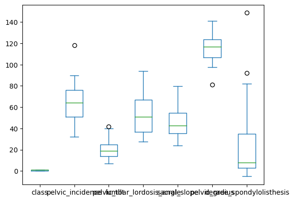

```python
test.plot.box()
```

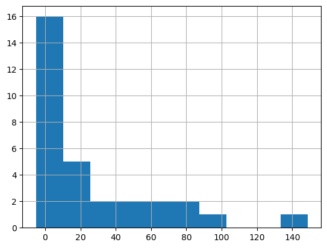

```python
test['degree_spondylolisthesis'].hist(bins=10)
```

```python
row = test.iloc[0:1,1:]
row.head()
```

|  | pelvic_incidence | pelvic_tilt | lumbar_lordosis_angle | sacral_slope | pelvic_radius | degree_spondylolisthesis |
| --- | --- | --- | --- | --- | --- | --- |
| 136 | 88.024499 | 39.844669 | 81.774473 | 48.17983 | 116.601538 | 56.766083 |

```python
import io
batch_X_csv_buffer = io.StringIO()
row.to_csv(batch_X_csv_buffer, header=False, index=False)
test_row = batch_X_csv_buffer.getvalue()
print(test_row)
```

```
88.0244989,39.84466878,81.77447308,48.17983012,116.6015376,56.76608323
```

```python
xgb_predictor.predict(test_row)
```

```
b'0.9966071844100952'
```

```python
test.head(5)
```

|  | class | pelvic_incidence | pelvic_tilt | lumbar_lordosis_angle | sacral_slope | pelvic_radius | degree_spondylolisthesis |
| --- | --- | --- | --- | --- | --- | --- | --- |
| 136 | 1 | 88.024499 | 39.844669 | 81.774473 | 48.179830 | 116.601538 | 56.766083 |
| 230 | 0 | 65.611802 | 23.137919 | 62.582179 | 42.473883 | 124.128001 | -4.083298 |
| 134 | 1 | 52.204693 | 17.212673 | 78.094969 | 34.992020 | 136.972517 | 54.939134 |
| 130 | 1 | 50.066786 | 9.120340 | 32.168463 | 40.946446 | 99.712453 | 26.766697 |
| 47 | 1 | 41.352504 | 16.577364 | 30.706191 | 24.775141 | 113.266675 | -4.497958 |

```python
xgb_predictor.delete_endpoint(delete_endpoint_config=True)
```

```
INFO:sagemaker:Deleting endpoint configuration with name: sagemaker-xgboost-2023-07-26-08-39-52-106
INFO:sagemaker:Deleting endpoint with name: sagemaker-xgboost-2023-07-26-08-39-52-106
```

```python
batch_X = test.iloc[:,1:];
batch_X.head()
```

|  | pelvic_incidence | pelvic_tilt | lumbar_lordosis_angle | sacral_slope | pelvic_radius | degree_spondylolisthesis |
| --- | --- | --- | --- | --- | --- | --- |
| 136 | 88.024499 | 39.844669 | 81.774473 | 48.179830 | 116.601538 | 56.766083 |
| 230 | 65.611802 | 23.137919 | 62.582179 | 42.473883 | 124.128001 | -4.083298 |
| 134 | 52.204693 | 17.212673 | 78.094969 | 34.992020 | 136.972517 | 54.939134 |
| 130 | 50.066786 | 9.120340 | 32.168463 | 40.946446 | 99.712453 | 26.766697 |
| 47 | 41.352504 | 16.577364 | 30.706191 | 24.775141 | 113.266675 | -4.497958 |

```python
batch_X_file='batch-in.csv'
upload_s3_csv(batch_X_file, 'batch-in', batch_X)
```

```python
batch_output = "s3://{}/{}/batch-out/".format(bucket,prefix)
batch_input = "s3://{}/{}/batch-in/{}".format(bucket,prefix,batch_X_file)

xgb_transformer = xgb_model.transformer(instance_count=1,
                                       instance_type='ml.m4.xlarge',
                                       strategy='MultiRecord',
                                       assemble_with='Line',
                                       output_path=batch_output)

xgb_transformer.transform(data=batch_input,
                         data_type='S3Prefix',
                         content_type='text/csv',
                         split_type='Line')
xgb_transformer.wait()
```

```
INFO:sagemaker:Creating model with name: sagemaker-xgboost-2023-07-26-08-47-24-527
INFO:sagemaker:Creating transform job with name: sagemaker-xgboost-2023-07-26-08-47-25-178
```

[output not shown]

[output cut: 86 more lines]

[output not shown]

```python
s3 = boto3.client('s3')
obj = s3.get_object(Bucket=bucket, Key="{}/batch-out/{}".format(prefix,'batch-in.csv.out'))
target_predicted = pd.read_csv(io.BytesIO(obj['Body'].read()),sep=',',names=['class'])
target_predicted.head(5)
```

```
INFO:botocore.credentials:Found credentials from IAM Role: BaseNotebookInstanceEc2InstanceRole
```

|  | class |
| --- | --- |
| 0 | 0.996607 |
| 1 | 0.777283 |
| 2 | 0.994641 |
| 3 | 0.993690 |
| 4 | 0.939139 |

```python
def binary_convert(x):
    threshold = 0.65
    if x > threshold:
        return 1
    else:
        return 0

target_predicted['binary'] = target_predicted['class'].apply(binary_convert)

print(target_predicted.head(10))
test.head(10)
```

```
      class  binary
0  0.996607       1
1  0.777283       1
2  0.994641       1
3  0.993690       1
4  0.939139       1
5  0.997396       1
6  0.991977       1
7  0.987518       1
8  0.993334       1
9  0.682776       1
```

|  | class | pelvic_incidence | pelvic_tilt | lumbar_lordosis_angle | sacral_slope | pelvic_radius | degree_spondylolisthesis |
| --- | --- | --- | --- | --- | --- | --- | --- |
| 136 | 1 | 88.024499 | 39.844669 | 81.774473 | 48.179830 | 116.601538 | 56.766083 |
| 230 | 0 | 65.611802 | 23.137919 | 62.582179 | 42.473883 | 124.128001 | -4.083298 |
| 134 | 1 | 52.204693 | 17.212673 | 78.094969 | 34.992020 | 136.972517 | 54.939134 |
| 130 | 1 | 50.066786 | 9.120340 | 32.168463 | 40.946446 | 99.712453 | 26.766697 |
| 47 | 1 | 41.352504 | 16.577364 | 30.706191 | 24.775141 | 113.266675 | -4.497958 |
| 135 | 1 | 77.121344 | 30.349874 | 77.481083 | 46.771470 | 110.611148 | 82.093607 |
| 100 | 1 | 84.585607 | 30.361685 | 65.479486 | 54.223922 | 108.010218 | 25.118478 |
| 89 | 1 | 71.186811 | 23.896201 | 43.696665 | 47.290610 | 119.864938 | 27.283985 |
| 297 | 0 | 45.575482 | 18.759135 | 33.774143 | 26.816347 | 116.797007 | 3.131910 |
| 4 | 1 | 49.712859 | 9.652075 | 28.317406 | 40.060784 | 108.168725 | 7.918501 |

```python
def binary_convert(x):
    threshold = 0.65
    if x > threshold:
        return 1
    else:
        return 0

target_predicted['binary'] = target_predicted['class'].apply(binary_convert)

print(target_predicted.head(10))
test.head
```

```
      class  binary
0  0.996607       1
1  0.777283       1
2  0.994641       1
3  0.993690       1
4  0.939139       1
5  0.997396       1
6  0.991977       1
7  0.987518       1
8  0.993334       1
9  0.682776       1
```

[output not shown]

[output cut: 50 more lines]

You work for a healthcare provider, and want to improve the detection of abnormalities in orthopedic patients.

You are tasked with solving this problem by using machine learning (ML). You have access to a dataset that contains six biomechanical features and a target of normal or abnormal. You can use this dataset to train an ML model to predict if a patient will have an abnormality.

Each patient is represented in the dataset by six biomechanical attributes that are derived from the shape and orientation of the pelvis and lumbar spine (in this order):

-> Pelvic incidence -> Pelvic tilt -> Lumbar lordosis angle -> Sacral slope -> Pelvic radius -> Grade of spondylolisthesis The following convention is used for the class labels:

-> DH (Disk Hernia) -> Spondylolisthesis (SL) -> Normal (NO) -> Abnormal (AB)